# Getting google scholar informations with R

> This documents provides a few line of codes to retrieve information from the google scholar API.

# 1 Load libraries

A few library are needed for this work, notably the scholar library that allows to call the google scholar API.

```r
library(rmarkdown)
library(scholar)      # To request data from google scholar.
library(tidyverse)    # What do you do without?
library(hrbrthemes)
library(DT)
```

# 2 Basic information about a researcher

In this document we will study the publication of my Colleague [Vincent Ranwez](https://sites.google.com/site/ranwez/). His google scholar ID is `WLaQnegAAAAJ&hl`

```r
# Define the google scholar id
id <- 'WLaQnegAAAAJ&hl'       # Vincent Ranwez
```

Get his profile and print his name

```r
# Make an object called l with all the basic info of this id: name, affiliation, # of cites, H index, homepage ...
l <- get_profile(id)
name=l$name
tmp=strsplit(name, " ") %>% unlist()
last_name = tmp[length(tmp)]

# Show the last name
last_name
```

```
## [1] "Ranwez"
```

# 3 Number of citation per year:

This allows to reproduce the chart on the right of the google scholar page:

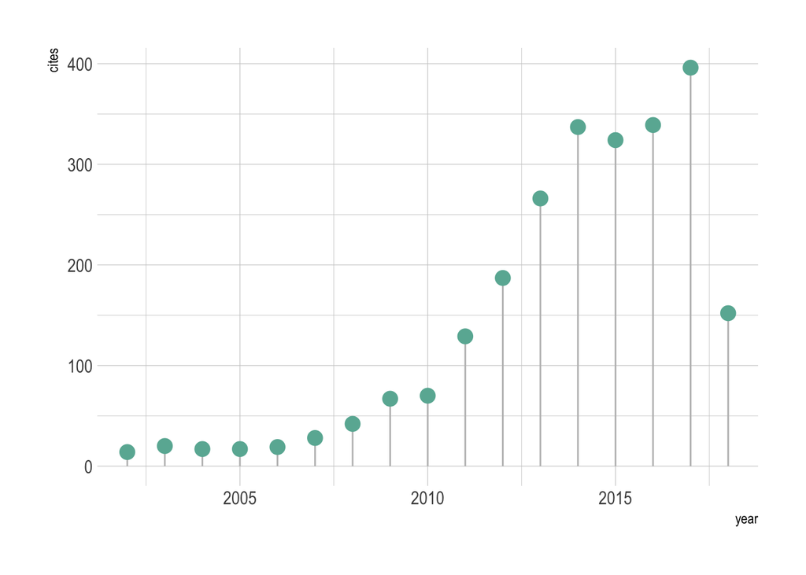

```r
# get the info
citation = get_citation_history(id)

# plot it
citation %>%
  ggplot( aes(x=year, y=cites)) +
    geom_segment( aes(x=year, y=0, xend=year, yend=cites), color="grey") +
    geom_point( size=4, col="#69b3a2") +
    theme_ipsum()
```

# 4 List of publications

Here is the detail of the publication:

```r
data=get_publications(id)
datatable(data, rownames = FALSE,  options = list(pageLength = 4))
```

| title | author | journal | number | cites | year | cid | pubid |
| --- | --- | --- | --- | --- | --- | --- | --- |
| MACSE: Multiple Alignment of Coding SEquences accounting for frameshifts and stop codons | V Ranwez, S Harispe, F Delsuc, EJP Douzery | PloS one | 6 (9), e22594 | 204 | 2011 | 3016315540992364455 | void(0) |
| A new versatile primer set targeting a short fragment of the mitochondrial COI region for metabarcoding metazoan diversity: application for characterizing coral reef fi... | M Leray, JY Yang, CP Meyer, SC Mills, N Agudelo, V Ranwez, JT Boehm, ... | Frontiers in zoology | 10 (1), 34 | 186 | 2013 | 7293087803628472709 | void(0) |
| GC-biased gene conversion promotes the fixation of deleterious amino acid changes in primates | N Galtier, L Duret, S Glémin, V Ranwez | Trends in Genetics | 25 (1), 1-5 | 133 | 2009 | 10081746445361617382 | void(0) |
| Contrasting GC-content dynamics across 33 mammalian genomes: relationship with life-history traits and chromosome sizes | J Romiguier, V Ranwez, EJP Douzery, N Galtier | Genome research | 20 (8), 1001-1009 | 131 | 2010 | 1262110133882085544 | void(0) |
| Multiple molecular evidences for a living mammalian fossil | D Huchon, P Chevret, U Jordan, CW Kilpatrick, V Ranwez, PD Jenkins, ... | Proceedings of the National Academy of Sciences | 104 (18), 7495-7499 | 123 | 2007 | 5571851739400155463 | void(0) |
| Reference‐free transcriptome assembly in non‐model animals from next‐generation sequencing data | V Cahais, P Gayral, G Tsagkogeorga, J Melo‐Ferreira, M Ballenghien, ... | Molecular ecology resources | 12 (5), 834-845 | 119 | 2012 | 16079713073567816195 | void(0) |
| Models, algorithms and programs for phylogeny reconciliation | JP Doyon, V Ranwez, V Daubin, V Berry | Briefings in bioinformatics | 12 (5), 392-400 | 119 | 2011 | 16387294310538028676 | void(0) |
| An efficient algorithm for gene/species trees parsimonious reconciliation with losses, duplications and transfers | JP Doyon, C Scornavacca, KY Gorbunov, GJ Szöllősi, V Ranwez, V Berry | RECOMB International Workshop on Comparative Genomics | 93-108 | 117 | 2010 | 5635864824939107508 | void(0) |
| Bio++: a set of C++ libraries for sequence analysis, phylogenetics, molecular evolution and population genetics | J Dutheil, S Gaillard, E Bazin, S Glémin, V Ranwez, N Galtier, K Belkhir | BMC bioinformatics | 7 (1), 188 | 114 | 2006 | 14075268693985375888 | void(0) |
| OrthoMaM: a database of orthologous genomic markers for placental mammal phylogenetics | V Ranwez, F Delsuc, S Ranwez, K Belkhir, MK Tilak, EJP Douzery | BMC evolutionary biology | 7 (1), 241 | 101 | 2007 | 13415726612864703145 | void(0) |

[output cut: 86 more lines]

# 5 Involved Journals?

In total, 96 paper have been published in 63 different journals. Here is an overview of the most frequent journals.

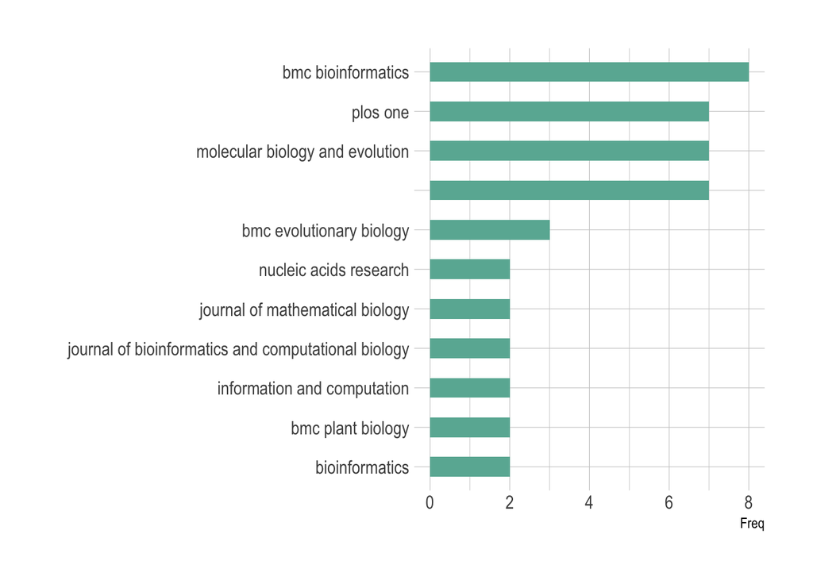

```r
table(tolower(data$journal)) %>% as.data.frame() %>% filter(Freq>1) %>% arrange(Freq) %>% mutate(Var1=factor(Var1, Var1)) %>%
  ggplot(aes(x=Var1, y=Freq)) +
    geom_bar(stat="identity", width=0.5, fill="#69b3a2") +
    coord_flip() +
    xlab("") +
    theme_ipsum()
```

# 6 Number of paper per year?

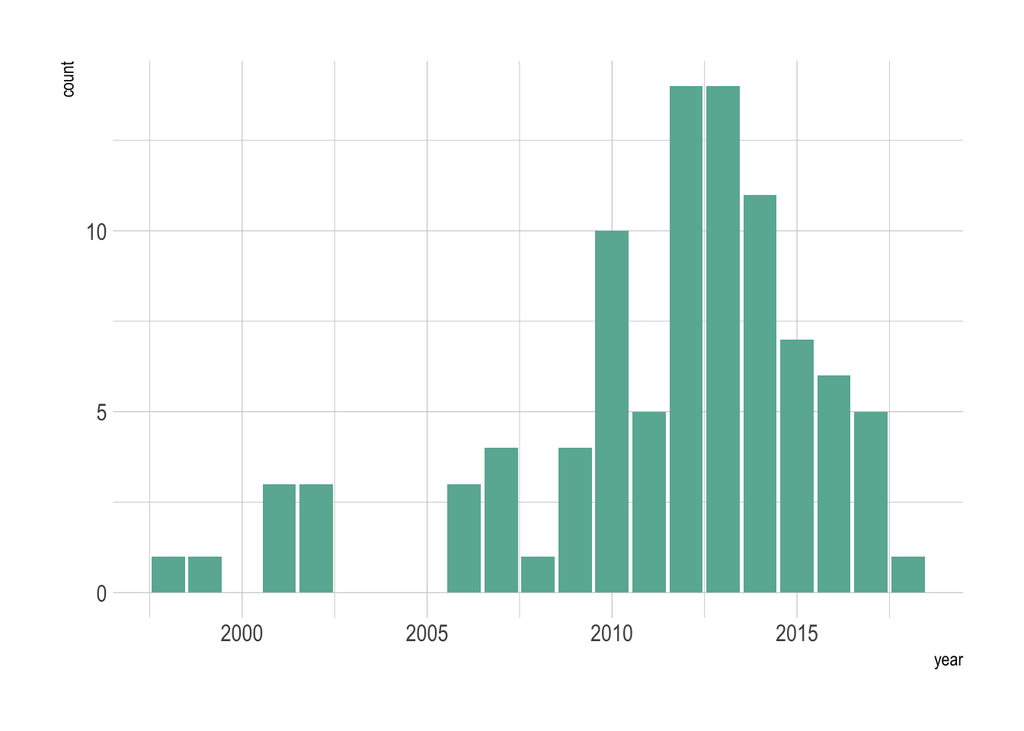

```r
data %>%
  ggplot(aes(x=year)) +
    geom_bar( fill="#69b3a2") +
    theme_ipsum()
```

# 7 Connection matrix of co-authors

Since the list of authors is available for each publication, it is possible to compute an adjacency matrix providing the relationship between every coauthors.

```r
# Compute all the pairs observed in the dataset:
return_all_pair=function(x){
  tmp = x  %>% gsub(", \\.\\.\\.", "", .) %>% strsplit(", ")  %>% unlist()
  if(length(tmp)>1){
    tmp = t(combn(tmp, 2))
  }
  return(tmp)
}
list_of_pairs = lapply( data$author, return_all_pair )
connect = do.call(rbind, list_of_pairs) %>% unique()
colnames(connect)=c("from", "to")

# Delete the target author from this list
connect = connect %>%
  as.data.frame() %>%
  filter( !grepl(last_name, from, ignore.case = TRUE) ) %>%
  filter( !grepl(last_name, to, ignore.case = TRUE) )

# Change format to adjacency matrix and save it
#connect %>%
#  mutate(value=1) %>%
#  spread(from, to)
```

In total, 133 co-authors have been found. But who are the most frequent coauthors?

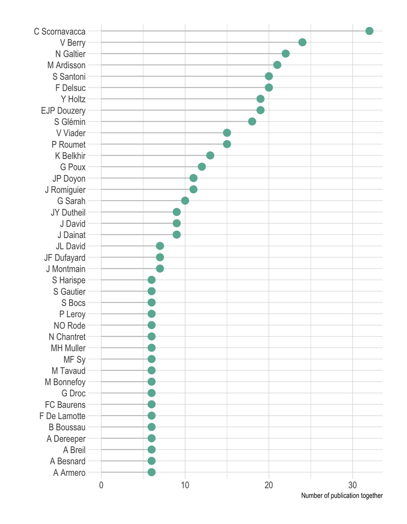

```r
c( as.character(connect$from), as.character(connect$to)) %>%
  table() %>%
  as.data.frame() %>%
  filter(Freq>5) %>%
  arrange(Freq) %>%
  mutate(Var1=factor(.,.)) %>%
    ggplot(aes(x=Var1, y=Freq)) +
      geom_segment( aes(x=Var1, y=0, xend=Var1, yend=Freq), color="grey") +
      geom_point( size=4, col="#69b3a2") +
      coord_flip() +
      xlab("") +
      theme_ipsum() +
      ylab("Number of publication together")
```

# 8 - Visualization

A work by [Swarna ravi](https://github.com/swarnaravi/)

*swarnaravistar@gmail.com*